# Experimentação Agronômica - Exemplos

José Genivaldo do Vale Moreira

2022-07-09

Neste material são apresentadas sugestões de soluções, executadas no R, para os exemplos do Livro Experimentação Agronômica & AgroEstat: Sistema para Análises Estatísticas de Ensaios Agronômicos. O livro será utilizado como referência principal no Curso de Extensão de **Análise de experimentos agronômicos com o *Software* R**.  
A escolha por este livro e não por obras clássicas como o Pimentel-Gomes (2009) e Banzatto & Kronka (2008) ou até mesmo o Design and Analysis of Experiments, de Dean & Voss (1999), se deu por muitos motivos, com destaque a dois: O primeiro se deve à qualidade do material produzido pelos autores José Carlos Barbosa e Walter Maldonado Júnior. O outro ponto se deu porque o livro apresenta os exemplos resolvidos por meio do *Software* AgroEstat. Isso permite ao aluno conferir os resultados obtidos no R e, ao final, terá familiaridade com dois bons *softwares* de apoio à análise de experimentos.  
Sugerimos uma leitura minuciosa dos exemplos à medida que acompanha os resultados apresentados no R.  
Segue informações da obra:  
BARBOSA, J. C.; MALDONADO JÚNIOR, W. **Experimentação Agronômica & AgroEstat: Sistema para análises de ensaios agronômicos**. Jaboticabal: Gráfica Multipress LTDA, 2015.

[figure not shown]

# Capítulo 1: Introdução

## Exemplo 1: Cálculo de medidas descritivas (pág. 4)

Considere como exemplo os dados seguntes, referentes ás alturas (cm) de 30 plantas de milho do cultivar OPACO 2, obtidos por Barbosa (1976):

### Inclusão dos dados

```r
dados1_1 <- c(232,218,207,188,227,228,185,217,202,207,220,234,178,213,
              188,175,207,200,195,189,215,217,213,218,192,195,181,207,
              220,225)
```

### Cálculo das medidas descritivas da amostra

```r
mean(dados1_1) # média dos dados
```

```
## [1] 206.4333
```

```r
var(dados1_1) # variância
```

```
## [1] 278.7368
```

```r
sd(dados1_1) # desvio-padrao
```

```
## [1] 16.69541
```

```r
summary(dados1_1) #sumário de medidas descritivas
```

```
##    Min. 1st Qu.  Median    Mean 3rd Qu.    Max.
##   175.0   192.8   207.0   206.4   218.0   234.0
```

```r
sd(dados1_1)/sqrt(length(dados1_1)) # erro padrão da média
```

```
## [1] 3.048151
```

```r
(sd(dados1_1)/mean(dados1_1))*100 # Coeficiente de variacao (CV)
```

```
## [1] 8.087556
```

### Obteção do gráfico boxplot dos dados

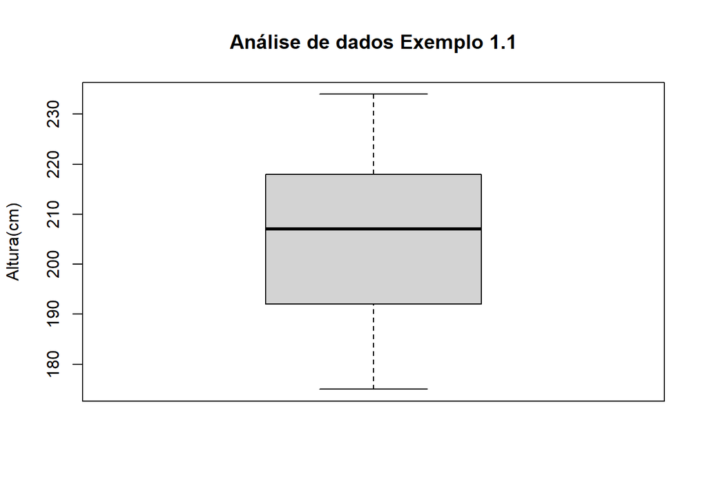

```r
boxplot(dados1_1, main="Análise de dados Exemplo 1.1",
        ylab = "Altura(cm)")
```

### Assimetria e curtose

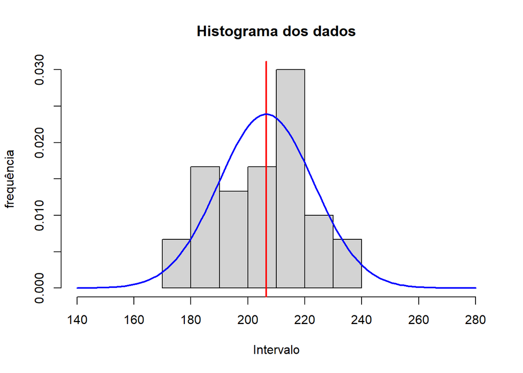

```r
hist(dados1_1,
     main = "Histograma dos dados",
     xlab = "Intervalo",
     ylab = "frequência",
     freq = FALSE,
     xlim = c(140,280))
abline(v=mean(dados1_1), col="red", lwd=2)
curve(dnorm(x, mean(dados1_1), sd(dados1_1)), add = TRUE,
      col="blue", lwd=2)
```

```r
library(e1071)

curtose1_1<-kurtosis(dados1_1, na.rm = TRUE, type = 2) #calcula a curtose
curtose1_1
```

```
## [1] -0.9793989
```

```r
assimetria1_1<-skewness(dados1_1, na.rm = TRUE, type = 2) #calcula a assimetria
assimetria1_1
```

```
## [1] -0.238824
```

### Exemplo média ponderada (Pág. 5)

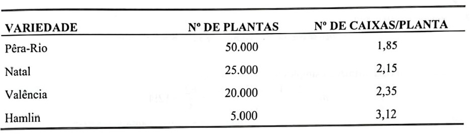

```r
#Inclusão dos dados
variedade = c("pera-rio", "natal", "valencia", "hamlin")
num_plantas = c(50000,25000,20000,5000)
caixa_por_planta = c(1.85,2.15,2.35,3.12)

#cálculo da média ponderada
media_pond = sum((num_plantas*caixa_por_planta))/sum(num_plantas)
media_pond
```

```
## [1] 2.0885
```

# Capítulo 4: Delineamento Inteiramente casualizado

## Exemplo 4.5 (Pág. 65)

Num experimento inteiramente casualizado, realizado por ZAMPIERI (1982), estudou-se o efeito da idade da semente sobre a capacidade de emergência e o vigor de semenentes de maracujá amarelo. Foram utilizados como tratamentos, sementes de 0,1,2,3,4 e 5 anos de idade, e os resultados obtidos para o comprimento médio do hipocótilo das plântulas (cm) foram os seguintes:

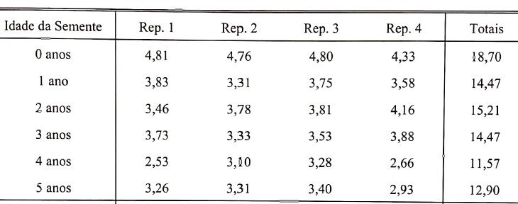

### Inclusão dos dados

```r
idade = c(rep("0anos",4), rep("1ano",4), rep("2anos",4), rep("3anos",4),
          rep("4anos",4), rep("5anos",4))
idade = as.factor(idade)
idade
```

```
##  [1] 0anos 0anos 0anos 0anos 1ano  1ano  1ano  1ano  2anos 2anos 2anos 2anos
## [13] 3anos 3anos 3anos 3anos 4anos 4anos 4anos 4anos 5anos 5anos 5anos 5anos
## Levels: 0anos 1ano 2anos 3anos 4anos 5anos
```

```r
comp_med = c(4.81,4.76,4.80,4.33,3.83,3.31,3.75,3.58,
             3.46,3.78,3.81,4.16,3.73,3.33,3.53,3.88,
             2.53,3.10,3.28,2.66,3.26,3.31,3.40,2.93)
comp_med
```

```
##  [1] 4.81 4.76 4.80 4.33 3.83 3.31 3.75 3.58 3.46 3.78 3.81 4.16 3.73 3.33 3.53
## [16] 3.88 2.53 3.10 3.28 2.66 3.26 3.31 3.40 2.93
```

```r
# banco de dados
dados4_5 = data.frame(idade, comp_med)
head(dados4_5, 10) # exibe apenas as 10 primeiras linhas
```

```
##    idade comp_med
## 1  0anos     4.81
## 2  0anos     4.76
## 3  0anos     4.80
## 4  0anos     4.33
## 5   1ano     3.83
## 6   1ano     3.31
## 7   1ano     3.75
## 8   1ano     3.58
## 9  2anos     3.46
## 10 2anos     3.78
```

As hipóteses a serem testadas são:  
H<sub>0</sub>: As idades das sementes testadas possuem efeitos semelhantes sobre o comprimento do hipocótilo das plântulas  
H<sub>A</sub>: As idades das sementes testadas possuem efeitos diferentes sobre o comprimento do hipocótilo das plântulas

### Determinação da anova

```r
anova4_5 = aov(comp_med ~ idade, data = dados4_5)
summary(anova4_5)
```

```
##             Df Sum Sq Mean Sq F value   Pr(>F)
## idade        5  7.318   1.464   21.23 5.67e-07 ***
## Residuals   18  1.241   0.069
## ---
## Signif. codes:  0 '***' 0.001 '**' 0.01 '*' 0.05 '.' 0.1 ' ' 1
```

Conclusão: Os resultados apontam para a rejeição de H<sub>0</sub> em favor da hipótese alternativa, permitindo concluir que as idades das sementes possuem efeitos diferentes sobre o comprimento do hipocótilo das plântulas de maracujá amarelo, ao nível de significância 5%.

### Análise dos pressupostos

#### Visualização gráfica prévia

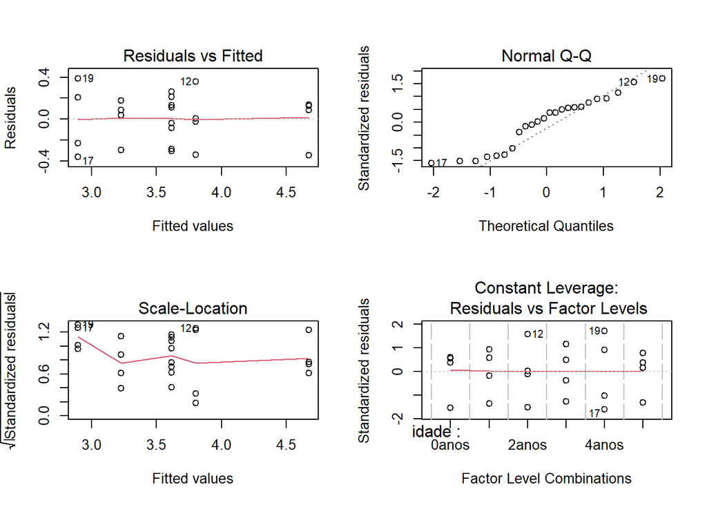

```r
par(mfrow=c(2,2)) #visualizar 4 gráficos na mesma figura (2 linas e 2 colunas)
plot(anova4_5) # plotar o gráfico
```

```r
par(mfrow=c(1,1)) # retornar a visualização gráfica normal
```

#### Normalidade dos resíduos

```r
residuos4_5 = anova4_5$residuals # cria um objeto com os resíduos do modelo

library(nortest)
shapiro.test(residuos4_5)
```

```
##
##  Shapiro-Wilk normality test
##
## data:  residuos4_5
## W = 0.92648, p-value = 0.08134
```

```r
ad.test(residuos4_5)
```

```
##
##  Anderson-Darling normality test
##
## data:  residuos4_5
## A = 0.66066, p-value = 0.07413
```

```r
lillie.test(residuos4_5)
```

```
##
##  Lilliefors (Kolmogorov-Smirnov) normality test
##
## data:  residuos4_5
## D = 0.14279, p-value = 0.2332
```

```r
ks.test(residuos4_5, "pnorm", mean(residuos4_5), sd(residuos4_5))
```

```
##
##  One-sample Kolmogorov-Smirnov test
##
## data:  residuos4_5
## D = 0.14279, p-value = 0.6602
## alternative hypothesis: two-sided
```

Verificou-se que os resíduos apresentaram normalidade (p-valor > 0,05)

#### Homogeneidade das variâncias

```r
library(car)
leveneTest(residuos4_5 ~ dados4_5$idade)
```

```
## Levene's Test for Homogeneity of Variance (center = median)
##       Df F value Pr(>F)
## group  5  0.6345 0.6761
##       18
```

```r
bartlett.test(residuos4_5 ~ dados4_5$idade)
```

```
##
##  Bartlett test of homogeneity of variances
##
## data:  residuos4_5 by dados4_5$idade
## Bartlett's K-squared = 1.1281, df = 5, p-value = 0.9516
```

Verificou-se homoneidade em relação aos resíduos (p > 0,05)

OBS: Aconselha-se uma leitura no item **4.3 Hipóteses básicas para aplicação da Análise de Variância**, do livro texto, página 59.

Uma vez rejeitada a hipótese de semelhança entre os tratamentos e os devidos pressupostos para aplicação da Anova, deve-se proceder com o **teste de comparação de médias**.  
Neste exemplo, serão utilizados três pacotes (packages) diferentes, para fins de aprendizado. Doravante utilizar-se-á somente o que mais se adequadar aos exercícios e à critério do autor deste material.

OBS: Confira os resultados obtidos como livro (pág. 68). Faça os cálculos, pois ajuda a fixar o conhecimento sobre o assunto.

Utilizando o pacote **ExpDes**

```r
library(ExpDes)
library(ExpDes.pt)
dic(dados4_5$idade, dados4_5$comp_med, quali = TRUE,mcomp = "tukey",
    nl = FALSE, hvar = "bartlett", sigT = 0.05, sigF = 0.05)
```

```
## ------------------------------------------------------------------------
## Quadro da analise de variancia
## ------------------------------------------------------------------------
##            GL     SQ      QM     Fc      Pr>Fc
## Tratamento  5 7.3184 1.46369 21.228 5.6661e-07
## Residuo    18 1.2411 0.06895
## Total      23 8.5595
## ------------------------------------------------------------------------
## CV = 7.22 %
##
## ------------------------------------------------------------------------
## Teste de normalidade dos residuos ( Shapiro-Wilk )
## Valor-p:  0.08133637
## De acordo com o teste de Shapiro-Wilk a 5% de significancia, os residuos podem ser considerados normais.
## ------------------------------------------------------------------------
##
## ------------------------------------------------------------------------
## Teste de homogeneidade de variancia
## valor-p:  0.9515869
## De acordo com o teste de bartlett a 5% de significancia, as variancias podem ser consideradas homogeneas.
## ------------------------------------------------------------------------
##
## Teste de Tukey
## ------------------------------------------------------------------------
## Grupos Tratamentos Medias
## a     0anos   4.675
##  b    2anos   3.8025
##  b    1ano    3.6175
##  b    3anos   3.6175
##  bc   5anos   3.225
##   c   4anos   2.8925
## ------------------------------------------------------------------------
```

Utilizando o pacote **agricolae**

```r
library(agricolae)
teste_ex4_5 = HSD.test(anova4_5,"idade",console=TRUE)
```

```
##
## Study: anova4_5 ~ "idade"
##
## HSD Test for comp_med
##
## Mean Square Error:  0.06895
##
## idade,  means
##
##       comp_med       std r  Min  Max
## 0anos   4.6750 0.2310123 4 4.33 4.81
## 1ano    3.6175 0.2299819 4 3.31 3.83
## 2anos   3.8025 0.2861672 4 3.46 4.16
## 3anos   3.6175 0.2393568 4 3.33 3.88
## 4anos   2.8925 0.3552816 4 2.53 3.28
## 5anos   3.2250 0.2050203 4 2.93 3.40
##
## Alpha: 0.05 ; DF Error: 18
## Critical Value of Studentized Range: 4.49442
##
## Minimun Significant Difference: 0.5900799
##
## Treatments with the same letter are not significantly different.
##
##       comp_med groups
## 0anos   4.6750      a
## 2anos   3.8025      b
## 1ano    3.6175      b
## 3anos   3.6175      b
## 5anos   3.2250     bc
## 4anos   2.8925      c
```

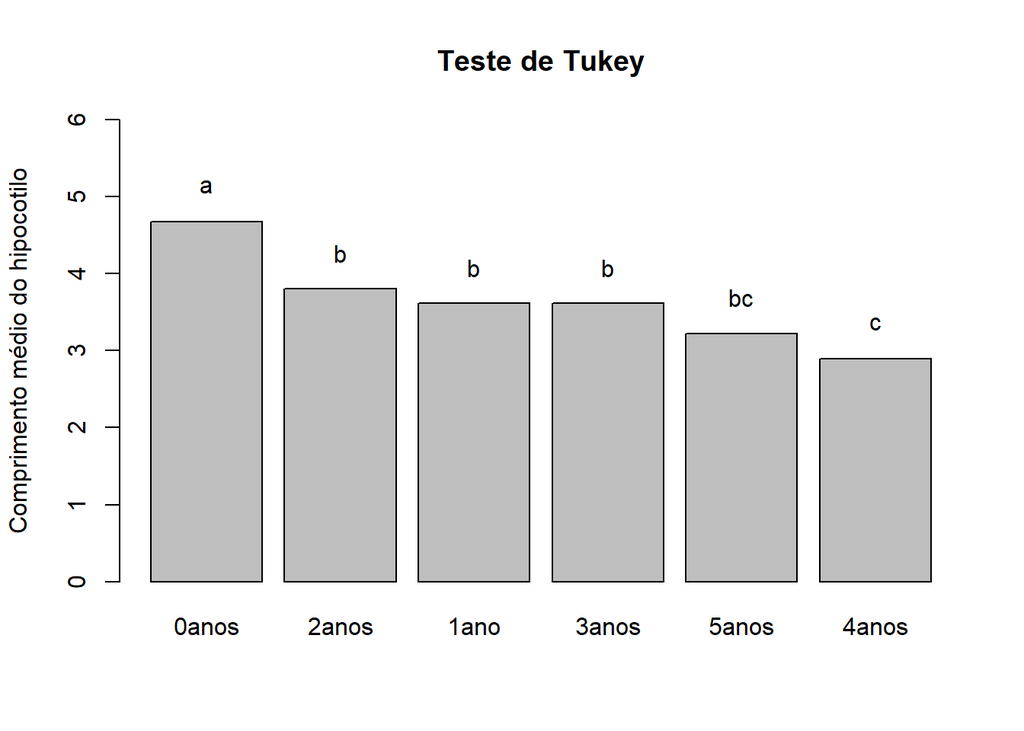

```r
bar.group(teste_ex4_5$groups,ylim=c(0,6), main = "Teste de Tukey",
          ylab = "Comprimento médio do hipocotilo")
```

Utilizando o pacote **easyanova**

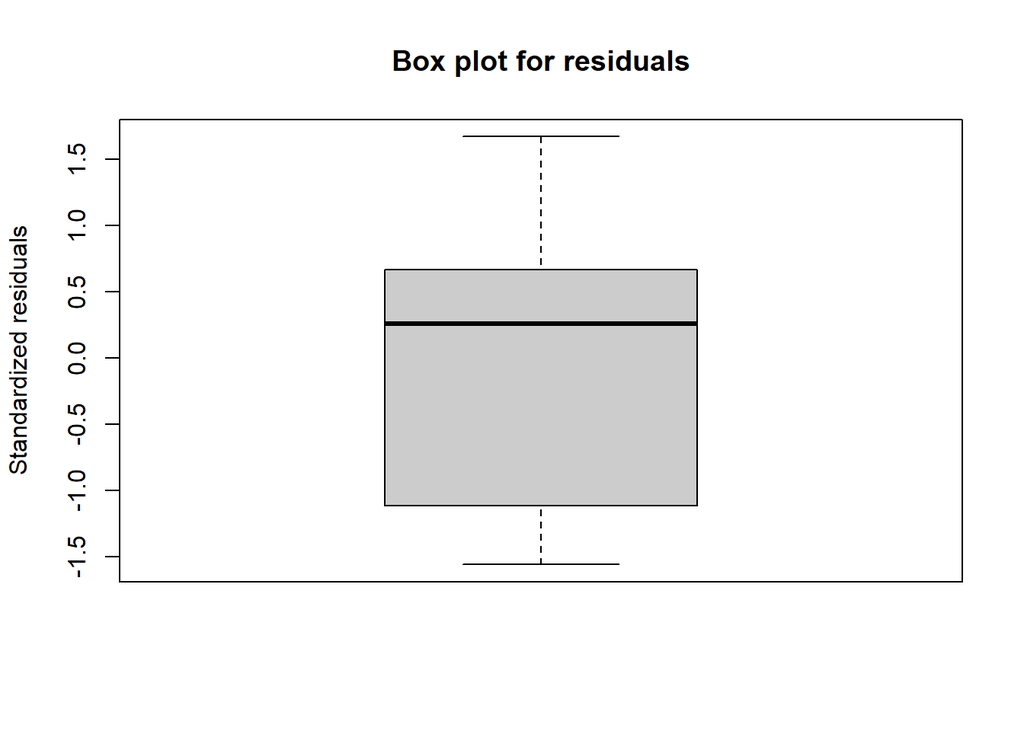

```r
library(easyanova)
ea4_5 = ea1(dados4_5, design = 1, alpha = 0.05, list = FALSE,
    p.adjust=1, plot=1)
```

```r
ea4_5$Means
```

[output not shown]

## Exemplo 4_6_2 (Pág. 69)

Análise de um experimento inteiramente casualizado não balanceado, referente ao número de ovos de adultos de *Spodoptera frugiperda*, cujas lagartas foram alimentadas com folhas de cultivares de amendoim, obtidos do trabalho de Campos (2011):

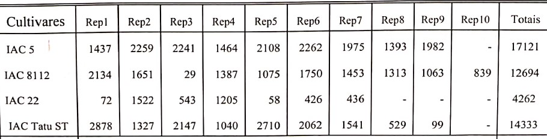

As hipóteses a serem testadas são:  
H<sub>0</sub>: As cultivares de amendoim não diferem entre si, quanto o número de ovos de *Spodoptera frugiperda*.  
H<sub>A</sub>: As cultivares de amendoim diferem entre si, quanto o número de ovos de *Spodoptera frugiperda*.

### Carregar os dados

Se você baixou o banco de dados deve tornar o diretório onde os salvou como direitório de trabalho (`ctrl + shift + H`), escolha o diretório e depois copie e cole o comando.  
`setwd("caminho do diretório")`  
Em seguida executar o comando para carregar os dados. `dados4_6_2 = read.csv("exemplo4_6_2", header = TRUE, sep = ";", dec = ".")`

Carregar os dados a partir do link.

```r
dados4_6_2 = read.csv("https://raw.githubusercontent.com/genivaldomoreira/Analise_experimentos_agronomicos/main/Dados/exemplo4_6_2.csv", header = TRUE, sep = ";", dec = ".")
head(dados4_6_2, 10) # exibir as 10 primeiras linhas para conferir
```

```
##    cultivares  rep quant
## 1        IAC5 rep1  1437
## 2        IAC5 rep2  2259
## 3        IAC5 rep3  2241
## 4        IAC5 rep4  1464
## 5        IAC5 rep5  2108
## 6        IAC5 rep6  2262
## 7        IAC5 rep7  1975
## 8        IAC5 rep8  1393
## 9        IAC5 rep9  1982
## 10    IAC8112 rep1  2134
```

Caso deseje visualizar o banco de dados completo, basta usar o comando `dados4_6_2`.

### Determinação da anova

```r
anova4_6_2 = aov(quant ~ cultivares, data = dados4_6_2)
summary(anova4_6_2) # conferir o resultado na pag 71
```

```
##             Df   Sum Sq Mean Sq F value  Pr(>F)
## cultivares   3  7146715 2382238   5.642 0.00332 **
## Residuals   31 13088799  422219
## ---
## Signif. codes:  0 '***' 0.001 '**' 0.01 '*' 0.05 '.' 0.1 ' ' 1
```

Conclusão: Deve-se rejeitar H<sub>0</sub> (p-valor < 0,05).

### Análise dos pressupostos

#### Visualização gráfica prévia

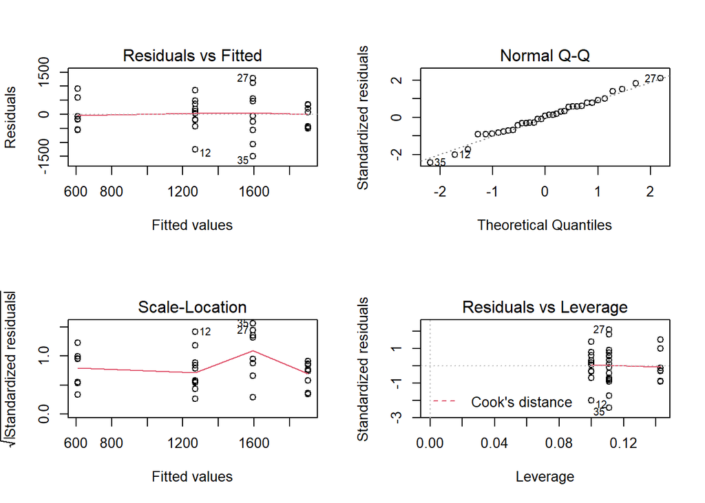

```r
par(mfrow=c(2,2)) #visualizar 4 gráficos na mesma figura (2 linhas e 2 colunas)
plot(anova4_6_2) # plotar o gráfico
```

```r
par(mfrow=c(1,1)) # retornar a visualização gráfica normal
```

#### Normalidade dos resíduos

```r
residuos4_6_2 = anova4_6_2$residuals # cria um objeto com os resíduos do modelo

library(nortest)
shapiro.test(residuos4_6_2)
```

```
##
##  Shapiro-Wilk normality test
##
## data:  residuos4_6_2
## W = 0.98293, p-value = 0.8494
```

```r
ad.test(residuos4_6_2)
```

```
##
##  Anderson-Darling normality test
##
## data:  residuos4_6_2
## A = 0.22839, p-value = 0.7961
```

```r
lillie.test(residuos4_6_2)
```

```
##
##  Lilliefors (Kolmogorov-Smirnov) normality test
##
## data:  residuos4_6_2
## D = 0.10087, p-value = 0.4894
```

```r
ks.test(residuos4_6_2, "pnorm", mean(residuos4_6_2), sd(residuos4_6_2))
```

```
##
##  One-sample Kolmogorov-Smirnov test
##
## data:  residuos4_6_2
## D = 0.10087, p-value = 0.8337
## alternative hypothesis: two-sided
```

Verificou-se que os resíduos apresentaram normalidade (p-valor > 0,05)

#### Homogeneidade das variâncias

```r
library(car)
leveneTest(residuos4_6_2 ~ dados4_6_2$cultivares)
```

```
## Levene's Test for Homogeneity of Variance (center = median)
##       Df F value  Pr(>F)
## group  3  2.3769 0.08894 .
##       31
## ---
## Signif. codes:  0 '***' 0.001 '**' 0.01 '*' 0.05 '.' 0.1 ' ' 1
```

```r
bartlett.test(residuos4_6_2 ~ dados4_6_2$cultivares)
```

```
##
##  Bartlett test of homogeneity of variances
##
## data:  residuos4_6_2 by dados4_6_2$cultivares
## Bartlett's K-squared = 6.7188, df = 3, p-value = 0.08142
```

Verificou-se homoneidade em relação aos resíduos (p > 0,05)

Uma vez rejeitada a hipótese de semelhança entre os tratamentos e os devidos pressupostos para aplicação da Anova, deve-se proceder com o **teste de comparação de médias**.

Utilizando o pacote **ExpDes**

```r
library(ExpDes)
library(ExpDes.pt)
dic(dados4_6_2$cultivares, dados4_6_2$quant, quali = TRUE,
    mcomp = "tukey",nl = FALSE, hvar = "bartlett",
    sigT = 0.05, sigF = 0.05)
```

[output not shown]

Utilizando o pacote **agricolae**

```r
library(agricolae)
teste_ex4_6_2 = HSD.test(anova4_6_2,"cultivares",console=TRUE, unbalanced = TRUE)
```

```
##
## Study: anova4_6_2 ~ "cultivares"
##
## HSD Test for quant
##
## Mean Square Error:  422219.3
##
## cultivares,  means
##
##                 quant      std  r  Min  Max
## IAC_Tatu_ST 1592.5556 946.6513  9   99 2878
## IAC22        608.8571 555.0569  7   58 1522
## IAC5        1902.3333 369.6762  9 1393 2262
## IAC8112     1269.4000 575.2098 10   29 2134
##
## Alpha: 0.05 ; DF Error: 31
## Critical Value of Studentized Range: 3.838277
##
## Groups according to probability of means differences and alpha level( 0.05 )
##
## Treatments with the same letter are not significantly different.
##
##                 quant groups
## IAC5        1902.3333      a
## IAC_Tatu_ST 1592.5556      a
## IAC8112     1269.4000     ab
## IAC22        608.8571      b
```

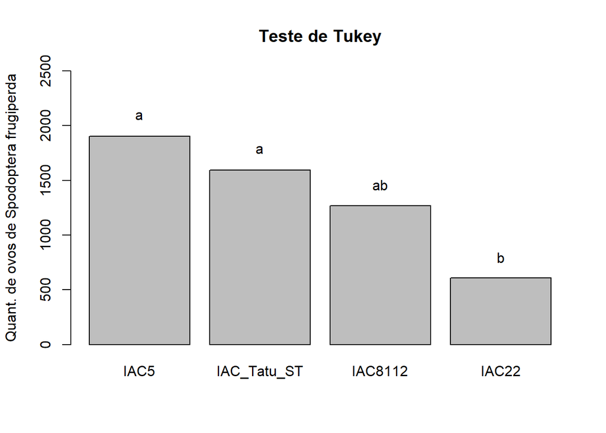

```r
bar.group(teste_ex4_6_2$groups,ylim=c(0,2500), main = "Teste de Tukey",ylab = "Quant. de ovos de Spodoptera frugiperda")
```

# Capítulo 5: Delineamento em Blocos Casualizados

## Exemplo 5.5 (Pág. 119)

Num experimento em blocos casualizados, realizados por ARF (1981), estudou-se o efeito de inseticidas no controle do tripes (*Enneothrips flavens* Moulton, 1941) na cultura do amendoim. Foram utilizados 7 tratamentos e 4 blocos, com os blocos controlando diferenças de infestação da cultura. Os resultados obtidos para a producao de vagens, em kg/ha, foram os seguintes:

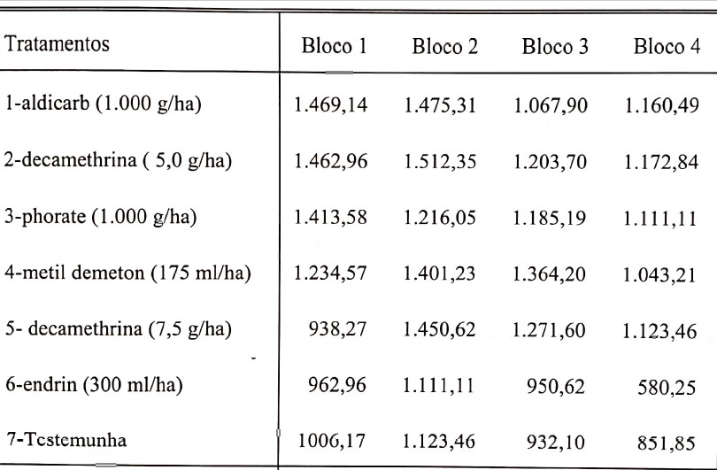

As hipóteses a serem testadas são:  
H<sub>0</sub>: Os inseticidas testados possuem efeitos semelhantes sobre a produção de vagens da cultura do amendoim.  
H<sub>A</sub>: Os inseticidas testados possuem efeitos diferentes sobre a produção de vagens da cultura do amendoim.

### Carregar os dados

Carregar os dados a partir do link.

```r
dados5_5 = read.csv("https://raw.githubusercontent.com/genivaldomoreira/Analise_experimentos_agronomicos/main/Dados/exemplo5_5.csv", header = TRUE, sep = ";", dec = ".")
head(dados5_5) # exibir as 6 primeiras linhas para conferir
```

```
##       tratamento  bloco producao
## 1       aldicarb bloco1  1469.14
## 2       aldicarb bloco2  1475.31
## 3       aldicarb bloco3  1067.90
## 4       aldicarb bloco4  1160.49
## 5 decamethrina_5 bloco1  1462.96
## 6 decamethrina_5 bloco2  1512.35
```

Caso deseje visualizar o banco de dados completo, basta usar o comando `dados5_5`.

### Determinação da anova

```r
anova5_5 = aov(producao ~ tratamento + bloco, data = dados5_5)
summary(anova5_5) # conferir o resultado na pag 121
```

```
##             Df Sum Sq Mean Sq F value   Pr(>F)
## tratamento   6 660112  110019   6.433 0.000935 ***
## bloco        3 379967  126656   7.405 0.001962 **
## Residuals   18 307860   17103
## ---
## Signif. codes:  0 '***' 0.001 '**' 0.01 '*' 0.05 '.' 0.1 ' ' 1
```

Conclusao: Para tratamentos: O Teste F foi significativo, ao nivel de significancia 1%, indicado que se deve rejeitar H<sub>0</sub>, permitindo concluir que os inceticidas possuem efeitos diferentes sobre a producao de vagens da cultura do amendoim. Para blocos: Rejeita-se H<sub>0</sub>.

### Análise dos pressupostos

#### Visualização gráfica prévia

```
## hat values (leverages) are all = 0.3571429
##  and there are no factor predictors; no plot no. 5
```

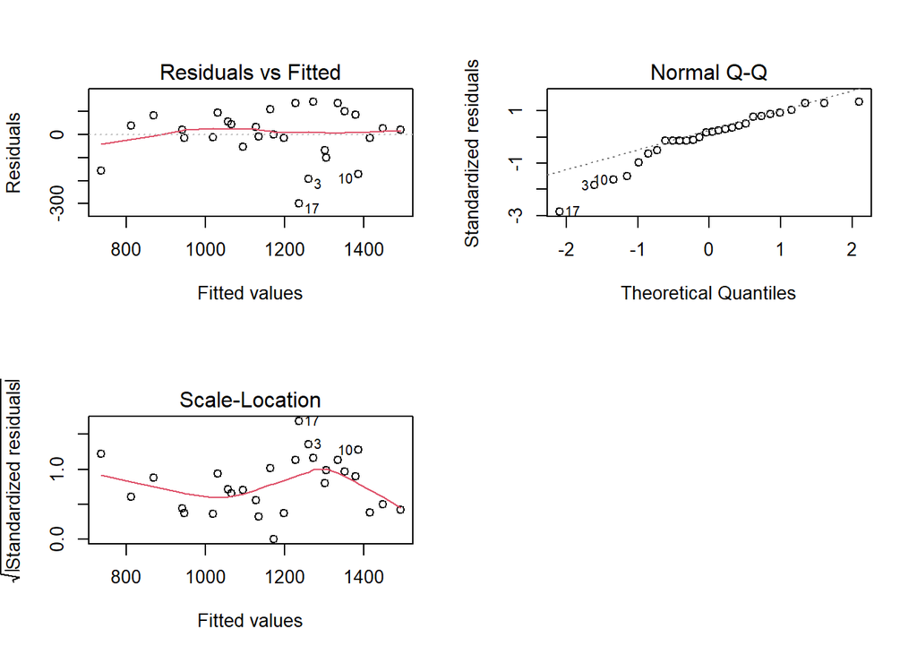

```r
par(mfrow=c(2,2)) #visualizar 4 gráficos na mesma figura (2 linhas e 2 colunas)
plot(anova5_5) # plotar o gráfico
```

```r
par(mfrow=c(1,1)) # retornar a visualização gráfica normal
```

#### Normalidade dos resíduos

```r
residuos5_5 = anova5_5$residuals # cria um objeto com os resíduos do modelo

library(nortest)
shapiro.test(residuos5_5)
```

```
##
##  Shapiro-Wilk normality test
##
## data:  residuos5_5
## W = 0.91954, p-value = 0.03379
```

```r
ad.test(residuos5_5)
```

```
##
##  Anderson-Darling normality test
##
## data:  residuos5_5
## A = 0.71151, p-value = 0.0562
```

```r
ks.test(residuos5_5, "pnorm", mean(residuos5_5), sd(residuos5_5))
```

```
##
##  One-sample Kolmogorov-Smirnov test
##
## data:  residuos5_5
## D = 0.19252, p-value = 0.2201
## alternative hypothesis: two-sided
```

#### Homogeneidade das variâncias

```r
library(car)
leveneTest(residuos5_5 ~ dados5_5$tratamento)
```

```
## Levene's Test for Homogeneity of Variance (center = median)
##       Df F value Pr(>F)
## group  6  0.3562 0.8982
##       21
```

```r
bartlett.test(residuos5_5 ~ dados5_5$tratamento)
```

```
##
##  Bartlett test of homogeneity of variances
##
## data:  residuos5_5 by dados5_5$tratamento
## Bartlett's K-squared = 8.9486, df = 6, p-value = 0.1765
```

Verificou-se homoneidade em relação aos resíduos (p > 0,05)

Uma vez rejeitada a hipótese de semelhança entre os tratamentos e os devidos pressupostos para aplicação da Anova, deve-se proceder com o **teste de comparação de médias**.

Utilizando o pacote **ExpDes**

```r
library(ExpDes)
library(ExpDes.pt)
dbc(dados5_5$tratamento, dados5_5$bloco, dados5_5$producao,
    quali = TRUE,mcomp = "tukey",nl = FALSE, hvar = "oneillmathews", sigT = 0.05, sigF = 0.05)
```

```
## ------------------------------------------------------------------------
## Quadro da analise de variancia
## ------------------------------------------------------------------------
##            GL      SQ     QM     Fc      Pr>Fc
## Tratamento  6  660112 110019 6.4326 0.00093451
## Bloco       3  379967 126656 7.4053 0.00196203
## Residuo    18  307860  17103
## Total      27 1347939
## ------------------------------------------------------------------------
## CV = 11.17 %
##
## ------------------------------------------------------------------------
## Teste de normalidade dos residuos
## valor-p:  0.03378852
## ATENCAO: a 5% de significancia, os residuos nao podem ser considerados normais!
## ------------------------------------------------------------------------
##
## ------------------------------------------------------------------------
## Teste de homogeneidade de variancia
## valor-p:  0.4215209
## De acordo com o teste de oneillmathews a 5% de significancia, as variancias podem ser consideradas homogeneas.
## ------------------------------------------------------------------------
##
## Teste de Tukey
## ------------------------------------------------------------------------
## Grupos Tratamentos Medias
## a     decamethrina_5      1337.963
## a     aldicarb    1293.21
## ab    metil_dematon   1260.803
## ab    phorate     1231.483
## abc   decamethrina_7      1195.987
##  bc   testemunha      978.395
##   c   endrin      901.235
## ------------------------------------------------------------------------
```

Utilizando o pacote **agricolae**

```r
library(agricolae)
teste_ex5_5 = HSD.test(anova5_5,"tratamento",console=TRUE)
```

```
##
## Study: anova5_5 ~ "tratamento"
##
## HSD Test for producao
##
## Mean Square Error:  17103.34
##
## tratamento,  means
##
##                producao      std r     Min     Max
## aldicarb       1293.210 210.1515 4 1067.90 1475.31
## decamethrina_5 1337.963 174.4775 4 1172.84 1512.35
## decamethrina_7 1195.987 217.7411 4  938.27 1450.62
## endrin          901.235 226.0735 4  580.25 1111.11
## metil_dematon  1260.803 161.7050 4 1043.21 1401.23
## phorate        1231.483 129.1384 4 1111.11 1413.58
## testemunha      978.395 115.4299 4  851.85 1123.46
##
## Alpha: 0.05 ; DF Error: 18
## Critical Value of Studentized Range: 4.673132
##
## Minimun Significant Difference: 305.5754
##
## Treatments with the same letter are not significantly different.
##
##                producao groups
## decamethrina_5 1337.963      a
## aldicarb       1293.210      a
## metil_dematon  1260.803     ab
## phorate        1231.483     ab
## decamethrina_7 1195.987    abc
## testemunha      978.395     bc
## endrin          901.235      c
```

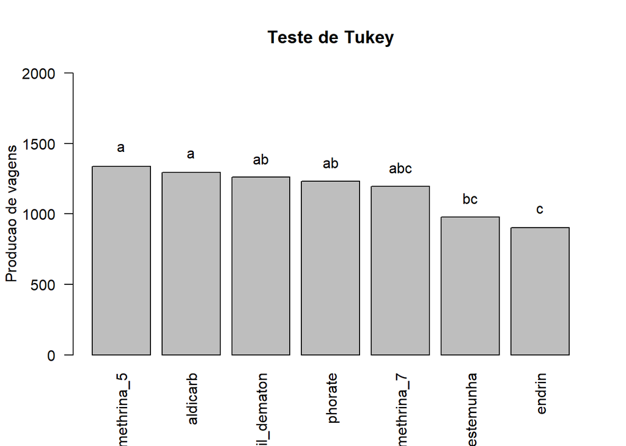

```r
bar.group(teste_ex5_5$groups,ylim=c(0,2000), main = "Teste de Tukey",ylab = "Producao de vagens", las=2)
```

## Exemplo 5.6.8 (Pág. 130)

Considerar os dados do item 5.5, porém, considerar como parcela perdiada o valor correspondente ao tratamento 6, no bloco 4:

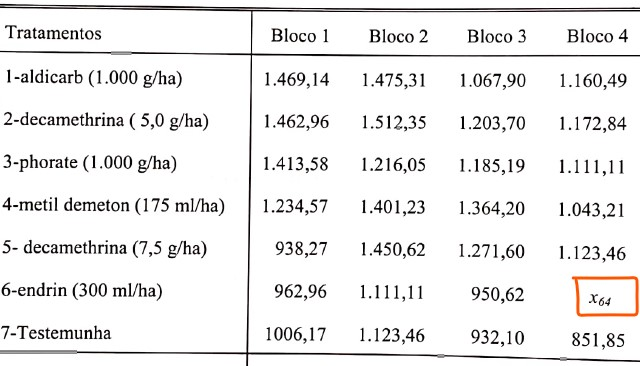

As hipóteses a serem testadas são:  
H<sub>0</sub>: Os inseticidas testados possuem efeitos semelhantes sobre a produção de vagens da cultura do amendoim.  
H<sub>A</sub>: Os inseticidas testados possuem efeitos diferentes sobre a produção de vagens da cultura do amendoim.

Carregar os dados a partir do link.

```r
dados5_6_8 = read.csv("https://raw.githubusercontent.com/genivaldomoreira/Analise_experimentos_agronomicos/main/Dados/exemplo5_6_8.csv", header = TRUE, sep = ";", dec = ".")
head(dados5_6_8) # exibir as 6 primeiras linhas para conferir
```

```
##       tratamento  bloco producao
## 1       aldicarb bloco1  1469.14
## 2       aldicarb bloco2  1475.31
## 3       aldicarb bloco3  1067.90
## 4       aldicarb bloco4  1160.49
## 5 decamethrina_5 bloco1  1462.96
## 6 decamethrina_5 bloco2  1512.35
```

### Determinação da anova

```r
anova5_6_8 = aov(producao ~ tratamento + bloco, data = dados5_6_8)
summary(anova5_6_8)
```

```
##             Df Sum Sq Mean Sq F value  Pr(>F)
## tratamento   6 435213   72535   4.566 0.00618 **
## bloco        3 280381   93460   5.883 0.00604 **
## Residuals   17 270071   15887
## ---
## Signif. codes:  0 '***' 0.001 '**' 0.01 '*' 0.05 '.' 0.1 ' ' 1
```

Para visualizar o resultado da Anova com o tratamento ajustado (pelo pacote agricolae) use o comando  
`BIB.test(dados5_6_8$bloco, dados5_6_8$tratamento, dados5_6_8$producao, test="lsd", alpha=0.05, group=FALSE, console=TRUE)`

### Análise dos pressupostos

#### Visualização gráfica prévia

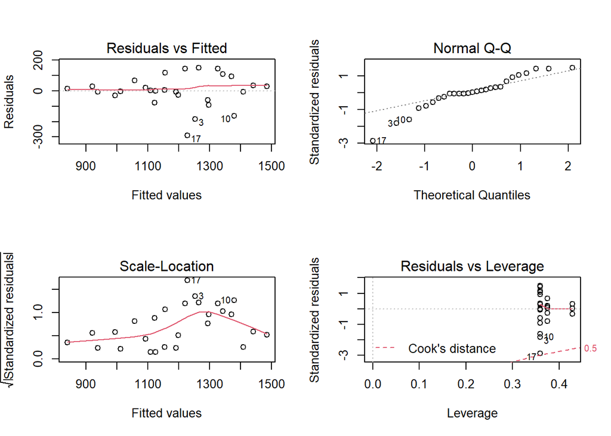

```r
par(mfrow=c(2,2)) #visualizar 4 gráficos na mesma figura (2 linhas e 2 colunas)
plot(anova5_6_8) # plotar o gráfico
```

```r
par(mfrow=c(1,1)) # retornar a visualização gráfica normal
```

#### Normalidade dos resíduos

```r
residuos5_6_8 = anova5_6_8$residuals # cria um objeto com os resíduos do modelo

library(nortest)
shapiro.test(residuos5_6_8)
```

```
##
##  Shapiro-Wilk normality test
##
## data:  residuos5_6_8
## W = 0.92479, p-value = 0.05156
```

```r
ad.test(residuos5_6_8)
```

```
##
##  Anderson-Darling normality test
##
## data:  residuos5_6_8
## A = 0.70114, p-value = 0.05943
```

```r
ks.test(residuos5_6_8, "pnorm", mean(residuos5_6_8), sd(residuos5_6_8))
```

```
##
##  One-sample Kolmogorov-Smirnov test
##
## data:  residuos5_6_8
## D = 0.17719, p-value = 0.3254
## alternative hypothesis: two-sided
```

Verificou-se que os resíduos apresentaram normalidade (p-valor > 0,05)

#### Homogeneidade das variâncias

```r
library(car)
leveneTest(residuos5_6_8 ~ dados5_6_8$tratamento)
```

[output not shown]

Verificou-se homoneidade em relação aos resíduos (p > 0,05)

Uma vez rejeitada a hipótese de semelhança entre os tratamentos e os devidos pressupostos para aplicação da Anova, deve-se proceder com o **teste de comparação de médias**.

Utilizando o pacote **easynova**

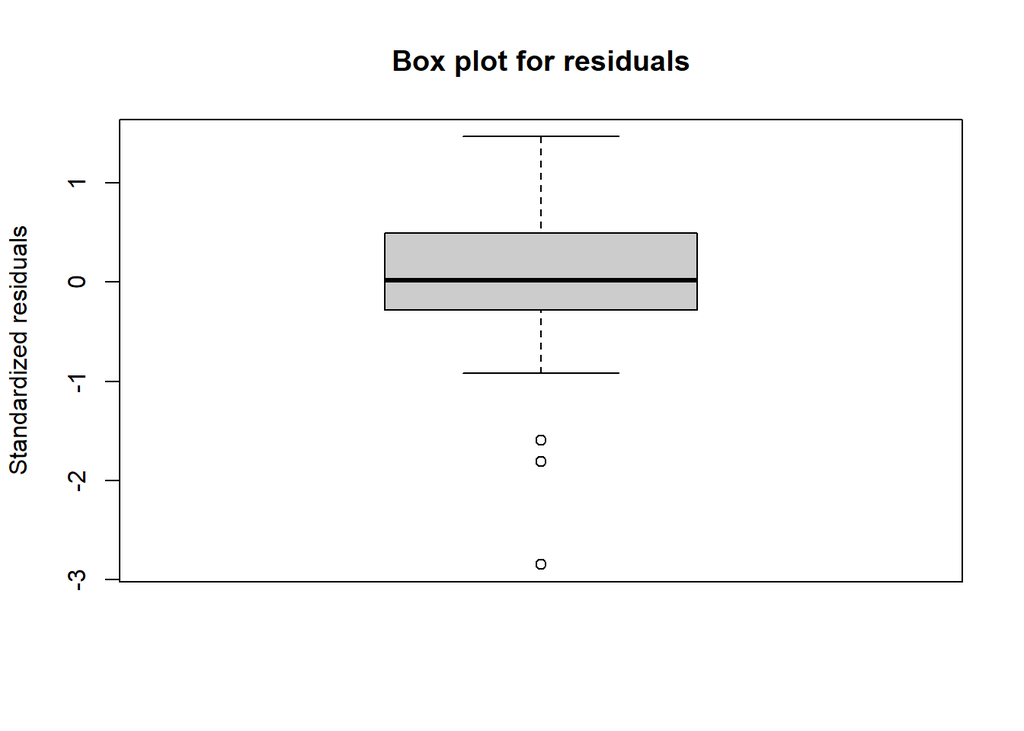

```r
library(easyanova)
comp5_6_8 = ea1(dados5_6_8, design = 8, alpha = 0.05, list = FALSE,
    p.adjust=1, plot=1)
```

```r
comp5_6_8$`Adjusted means`
```

```
##        treatment adjusted.mean standard.error tukey snk duncan t scott_knott
## 1 decamethrina_5     1337.9625        63.0209     a   a      a a           a
## 2       aldicarb     1293.2100        63.0209     a   a      a a           a
## 3  metil_dematon     1260.8025        63.0209    ab   a      a a           a
## 4        phorate     1231.4825        63.0209    ab  ab      a a           a
## 5 decamethrina_7     1195.9875        63.0209    ab  ab      a a           a
## 6     testemunha      978.3950        63.0209     b   c      b b           b
## 7         endrin      961.8478        74.2709     b  bc      b b           b
```

## Exemplo 5.8.6 (Pág. 149)

Considerando os dados adaptados do trabalho intitulado “Comparação de métodos para patologia de sementes de sorgo *Sorghum bicolor* (L.) Moench”, realizado pos SALATI (1986), onde estudou-se a porcentagem de incidência de *Alternaria tenuis* sp., nas sementes de 7 cultivares de sorgo. Os dados obtidos, transformados em $arcsen(\sqrt{(p/100)})$:

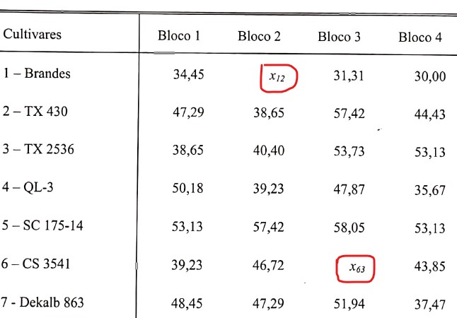

As hipóteses a serem testadas são:  
H<sub>0</sub>: As cultivares de sorgo testadas não diferem entre si em relação à porcentagem de incidência de *Alternaria tenuis* sp. nas sementes.  
H<sub>A</sub>: As cultivares de sorgo testadas diferem entre si em relação à porcentagem de incidência de *Alternaria tenuis* sp. nas sementes.

Carregar os dados a partir do link.

```r
dados5_8_6 = read.csv("https://raw.githubusercontent.com/genivaldomoreira/Analise_experimentos_agronomicos/main/Dados/exemplo5_8_6.csv", header = TRUE, sep = ";", dec = ".")
head(dados5_8_6, 10) # exibir as 10 primeiras linhas para conferir
```

```
##    cultivares  bloco incidencia
## 1     Brandes bloco1      34.45
## 2     Brandes bloco3      31.31
## 3     Brandes bloco4      30.00
## 4       TX430 bloco1      47.29
## 5       TX430 bloco2      38.65
## 6       TX430 bloco3      57.42
## 7       TX430 bloco4      44.43
## 8      TX2536 bloco1      38.65
## 9      TX2536 bloco2      40.40
## 10     TX2536 bloco3      53.73
```

### Determinação da anova

```r
anova5_8_6 = aov(incidencia ~ cultivares + bloco, data = dados5_8_6)
summary(anova5_8_6)
```

```
##             Df Sum Sq Mean Sq F value  Pr(>F)
## cultivares   6  997.4  166.23   5.559 0.00279 **
## bloco        3  220.3   73.45   2.456 0.10055
## Residuals   16  478.5   29.91
## ---
## Signif. codes:  0 '***' 0.001 '**' 0.01 '*' 0.05 '.' 0.1 ' ' 1
```

Para visualizar o resultado da Anova com o tratamento ajustado (pelo pacote agricolae) use o comando  
`BIB.test(dados5_8_6$bloco, dados5_8_6$cultivares, dados5_8_6$incidencia, test="lsd", alpha=0.05, group=FALSE, console=TRUE)`

### Análise dos pressupostos

#### Visualização gráfica prévia

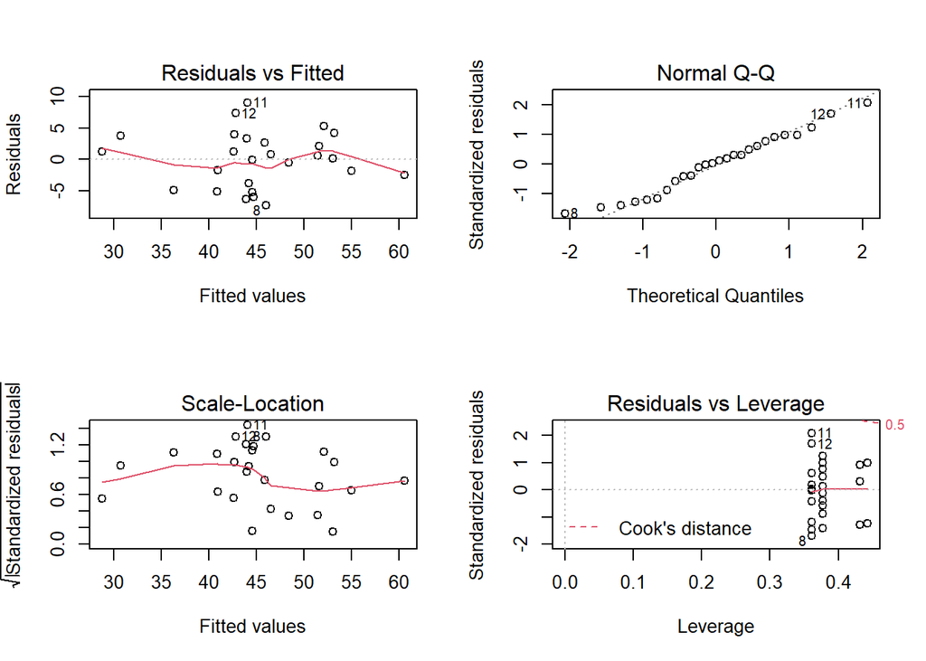

```r
par(mfrow=c(2,2)) #visualizar 4 gráficos na mesma figura (2 linhas e 2 colunas)
plot(anova5_8_6) # plotar o gráfico
```

```r
par(mfrow=c(1,1)) # retornar a visualização gráfica normal
```

#### Normalidade dos resíduos

```r
residuos5_8_6 = anova5_8_6$residuals # cria um objeto com os resíduos do modelo

library(nortest)
shapiro.test(residuos5_8_6)
```

```
##
##  Shapiro-Wilk normality test
##
## data:  residuos5_8_6
## W = 0.97494, p-value = 0.7528
```

```r
ad.test(residuos5_8_6)
```

```
##
##  Anderson-Darling normality test
##
## data:  residuos5_8_6
## A = 0.21531, p-value = 0.8292
```

```r
ks.test(residuos5_8_6, "pnorm", mean(residuos5_8_6), sd(residuos5_8_6))
```

```
##
##  One-sample Kolmogorov-Smirnov test
##
## data:  residuos5_8_6
## D = 0.10332, p-value = 0.9174
## alternative hypothesis: two-sided
```

Verificou-se que os resíduos apresentaram normalidade (p-valor > 0,05)

#### Homogeneidade das variâncias

```r
library(car)
leveneTest(residuos5_8_6 ~ dados5_8_6$cultivares)
```

```
## Levene's Test for Homogeneity of Variance (center = median)
##       Df F value Pr(>F)
## group  6  0.4529  0.834
##       19
```

```r
bartlett.test(residuos5_8_6 ~ dados5_8_6$cultivares)
```

```
##
##  Bartlett test of homogeneity of variances
##
## data:  residuos5_8_6 by dados5_8_6$cultivares
## Bartlett's K-squared = 2.0014, df = 6, p-value = 0.9196
```

Verificou-se homoneidade em relação aos resíduos (p > 0,05)

Uma vez rejeitada a hipótese de semelhança entre os tratamentos e os devidos pressupostos para aplicação da Anova, deve-se proceder com o **teste de comparação de médias**.

Utilizando o pacote **ExpDes**

```r
library(ExpDes)
library(ExpDes.pt)
dbc(dados5_8_6$cultivares, dados5_8_6$bloco, dados5_8_6$incidencia,quali = TRUE, mcomp = "tukey",
    hvar = "oneillmathews", sigT = 0.05, sigF = 0.05)
```

```
## ------------------------------------------------------------------------
## Quadro da analise de variancia
## ------------------------------------------------------------------------
##            GL      SQ      QM     Fc    Pr>Fc
## Tratamento  6  997.40 166.234 5.5586 0.002789
## Bloco       3  220.34  73.446 2.4559 0.100548
## Residuo    16  478.49  29.906
## Total      25 1696.23
## ------------------------------------------------------------------------
## CV = 12.06 %
##
## ------------------------------------------------------------------------
## Teste de normalidade dos residuos
## valor-p:  0.7528053
## De acordo com o teste de Shapiro-Wilk a 5% de significancia, os residuos podem ser considerados normais.
## ------------------------------------------------------------------------
##
## ------------------------------------------------------------------------
## Teste de homogeneidade de variancia
## valor-p:  0.5989874
## De acordo com o teste de oneillmathews a 5% de significancia, as variancias podem ser consideradas homogeneas.
## ------------------------------------------------------------------------
##
## Teste de Tukey
## ------------------------------------------------------------------------
## Grupos Tratamentos Medias
## a     SC175-14    55.4325
## a     TX430   46.9475
## a     TX2536      46.4775
## a     Dekalb863   46.2875
## ab    CS3541      43.26667
## ab    QL-3    43.2375
##  b    Brandes     31.92
## ------------------------------------------------------------------------
```

## Exemplo 5.9.2 (Pág. 160)

Os dados a seguir foram obtidos do trabalho intitulado “Estudo comparativo entre diferentes métodos de semeadura na cultura do mamoeiro (*Carica papaya* L.)”, realizado por Ruiz (1977), onde estudaram-se os efeitos de três métodos de semeadura sobre diversas características das mudas de mamoeiro. Os tratamentos utilizados foram: A - Semeadura direta no campo; B - Semeadura em recipientes a pleno sol; C - Semeadura em recipientes no ripado.  
Os dados obtidos para a pocentagem média de pegamento, transformados em *Arco seno* $sqrt(p/100)$:

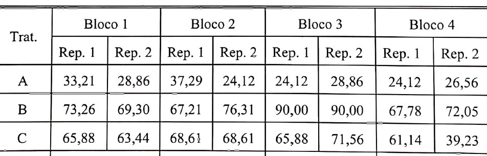

As hipóteses a serem testadas são:  
H<sub>0</sub>: Os métodos de semeadura testados possuem efeitos semelhantes sobre a porcentagem média de pegamento das mudas do mamoeiro.  
H<sub>A</sub>: Os métodos de semeadura testados possuem efeitos diferentes sobre a porcentagem média de pegamento das mudas do mamoeiro.

Carregar os dados a partir do link.

```r
dados5_9_2 = read.csv("https://raw.githubusercontent.com/genivaldomoreira/Analise_experimentos_agronomicos/main/Dados/exemplo5_9_2.csv", header = TRUE, sep = ";", dec = ".")
head(dados5_9_2, 10) # exibir as 10 primeiras linhas para conferir
```

```
##    tratamento  bloco pegamento
## 1       tratA bloco1     33.21
## 2       tratA bloco1     28.86
## 3       tratA bloco2     37.29
## 4       tratA bloco2     24.12
## 5       tratA bloco3     24.12
## 6       tratA bloco3     28.86
## 7       tratA bloco4     24.12
## 8       tratA bloco4     26.56
## 9       tratB bloco1     73.26
## 10      tratB bloco1     69.30
```

### Determinação da anova

```r
anova5_9_2 = aov(pegamento~tratamento+bloco, data = dados5_9_2)
summary(anova5_9_2)
```

```
##             Df Sum Sq Mean Sq F value   Pr(>F)
## tratamento   2   9610    4805  91.569 3.68e-10 ***
## bloco        3    542     181   3.442   0.0389 *
## Residuals   18    944      52
## ---
## Signif. codes:  0 '***' 0.001 '**' 0.01 '*' 0.05 '.' 0.1 ' ' 1
```

### Análise dos pressupostos

#### Visualização gráfica prévia

```
## hat values (leverages) are all = 0.25
##  and there are no factor predictors; no plot no. 5
```

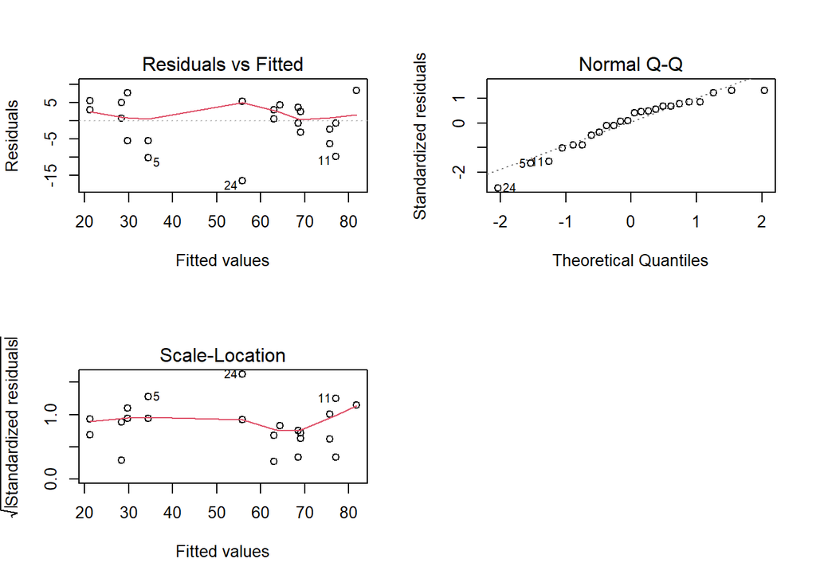

```r
par(mfrow=c(2,2)) #visualizar 4 gráficos na mesma figura (2 linhas e 2 colunas)
plot(anova5_9_2) # plotar o gráfico
```

```r
par(mfrow=c(1,1)) # retornar a visualização gráfica normal
```

#### Normalidade dos resíduos

```r
residuos5_9_2 = anova5_9_2$residuals # cria um objeto com os resíduos do modelo

library(nortest)
shapiro.test(residuos5_9_2)
```

```
##
##  Shapiro-Wilk normality test
##
## data:  residuos5_9_2
## W = 0.93005, p-value = 0.09771
```

```r
ad.test(residuos5_9_2)
```

```
##
##  Anderson-Darling normality test
##
## data:  residuos5_9_2
## A = 0.54706, p-value = 0.1426
```

```r
ks.test(residuos5_9_2, "pnorm", mean(residuos5_9_2), sd(residuos5_9_2))
```

```
##
##  One-sample Kolmogorov-Smirnov test
##
## data:  residuos5_9_2
## D = 0.15199, p-value = 0.6362
## alternative hypothesis: two-sided
```

Verificou-se que os resíduos apresentaram normalidade (p-valor > 0,05)

#### Homogeneidade das variâncias

```r
library(car)
leveneTest(residuos5_9_2 ~ dados5_9_2$tratamento)
```

```
## Levene's Test for Homogeneity of Variance (center = median)
##       Df F value Pr(>F)
## group  2  0.0924 0.9121
##       21
```

```r
bartlett.test(residuos5_9_2 ~ dados5_9_2$tratamento)
```

```
##
##  Bartlett test of homogeneity of variances
##
## data:  residuos5_9_2 by dados5_9_2$tratamento
## Bartlett's K-squared = 0.11641, df = 2, p-value = 0.9435
```

Verificou-se homoneidade em relação aos resíduos (p > 0,05)

Uma vez rejeitada a hipótese de semelhança entre os tratamentos e os devidos pressupostos para aplicação da Anova, deve-se proceder com o **teste de comparação de médias**.

Utilizando o pacote **ExpDes**

```r
library(ExpDes)
library(ExpDes.pt)
dbc(dados5_9_2$tratamento, dados5_9_2$bloco, dados5_9_2$pegamento,
    quali = TRUE, mcomp = "tukey", hvar = "oneillmathews",
    sigT = 0.05, sigF = 0.05)
```

```
## ------------------------------------------------------------------------
## Quadro da analise de variancia
## ------------------------------------------------------------------------
##            GL      SQ     QM     Fc   Pr>Fc
## Tratamento  2  9609.6 4804.8 91.569 0.00000
## Bloco       3   541.8  180.6  3.442 0.03888
## Residuo    18   944.5   52.5
## Total      23 11095.9
## ------------------------------------------------------------------------
## CV = 13 %
##
## ------------------------------------------------------------------------
## Teste de normalidade dos residuos
## valor-p:  0.0977143
## De acordo com o teste de Shapiro-Wilk a 5% de significancia, os residuos podem ser considerados normais.
## ------------------------------------------------------------------------
##
## ------------------------------------------------------------------------
## Teste de homogeneidade de variancia
## valor-p:  1
## De acordo com o teste de oneillmathews a 5% de significancia, as variancias podem ser consideradas homogeneas.
## ------------------------------------------------------------------------
##
## Teste de Tukey
## ------------------------------------------------------------------------
## Grupos Tratamentos Medias
## a     tratB   75.73875
##  b    tratC   63.045
##   c   tratA   28.3925
## ------------------------------------------------------------------------
```

Utilizando o **easyanova**

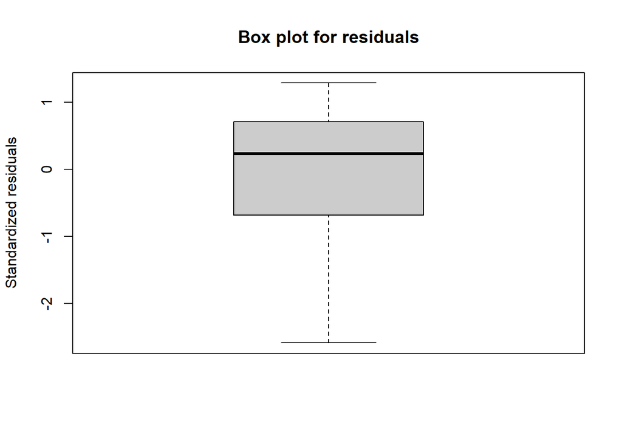

```r
library(easyanova)
ea5_9_2 = ea1(dados5_9_2, design = 2, alpha = 0.05,
    list = FALSE, p.adjust=1, plot=1)
```

```r
ea5_9_2$`Analysis of variance`
```

```
##            df type III SS mean square F value    p>F
## treatments  2   9609.5852   4804.7926  91.569 <0.001
## blocks      3    541.8027    180.6009  3.4419 0.0389
## residuals  18    944.4929     52.4718       -      -
```

```r
ea5_9_2$`Adjusted means`
```

```
##   treatment adjusted.mean standard.error tukey snk duncan t scott_knott
## 1     tratB       75.7388         2.5611     a   a      a a           a
## 2     tratC       63.0450         2.5611     b   b      b b           b
## 3     tratA       28.3925         2.5611     c   c      c c           c
```

Utilizando o **agricolae**

```r
library(agricolae)
teste5_9_2 = HSD.test(anova5_9_2,"tratamento",console=TRUE)
```

```
##
## Study: anova5_9_2 ~ "tratamento"
##
## HSD Test for pegamento
##
## Mean Square Error:  52.47183
##
## tratamento,  means
##
##       pegamento       std r   Min   Max
## tratA  28.39250  4.794815 8 24.12 37.29
## tratB  75.73875  9.291953 8 67.21 90.00
## tratC  63.04500 10.148759 8 39.24 71.56
##
## Alpha: 0.05 ; DF Error: 18
## Critical Value of Studentized Range: 3.609304
##
## Minimun Significant Difference: 9.243608
##
## Treatments with the same letter are not significantly different.
##
##       pegamento groups
## tratB  75.73875      a
## tratC  63.04500      b
## tratA  28.39250      c
```

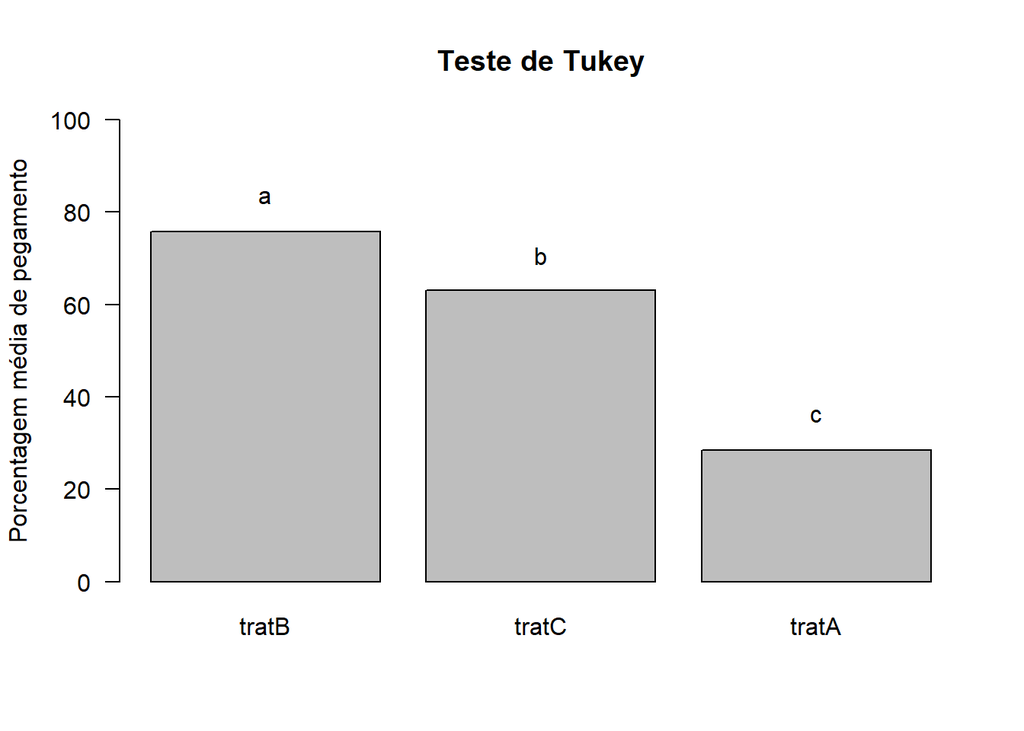

```r
bar.group(teste5_9_2$groups,ylim=c(0,100), main = "Teste de Tukey",
          ylab = "Porcentagem média de pegamento", las=1)
```